# Modelado de estructuras latentes: análisis factorial aplicado a los intereses de jóvenes

Ana Milena Uribe; Alejandro Quintero; Francisco Mario Campo; Pablo Stevens Casilimas

Octubre de 2026

# 1 Resumen metodológico

Se aplica una partición previa e independiente de la muestra: una submuestra para descubrir y depurar la estructura mediante AFE y otra para contrastarla mediante AFC. Los ítems se tratan como ordinales. Se comparan soluciones de 4, 6 y 8 factores, incluida la sugerencia de 8 factores del análisis paralelo policórico. La sintaxis confirmatoria se genera automáticamente desde cada solución AFE, evitando reutilizar una estructura manual anterior.

# 2 Datos y preparación

```r
archivos <- c("datos/responses.csv","datos/columns.csv")
if(!all(file.exists(archivos))) stop("Faltan archivos: ",paste(archivos[!file.exists(archivos)],collapse=", "))
respuestas <- read.csv(archivos[1],check.names=FALSE)
diccionario <- read.csv(archivos[2],check.names=FALSE)
ini <- match("History",names(respuestas)); fin <- match("Pets",names(respuestas))
if(is.na(ini)||is.na(fin)) stop("No se localizaron History y Pets.")
items_originales <- names(respuestas)[ini:fin]
if(length(items_originales)!=32L) stop("Se esperaban 32 ítems y se hallaron ",length(items_originales),".")
X0 <- respuestas[,items_originales,drop=FALSE]
flujo <- tibble(etapa=c("Registros originales","Con al menos un faltante","Casos completos"),
                n=c(nrow(X0),sum(!complete.cases(X0)),sum(complete.cases(X0))))
write.csv(flujo,"resultados/00_flujo_muestra.csv",row.names=FALSE)
X <- X0[complete.cases(X0),,drop=FALSE]
names(X) <- make.names(names(X),unique=TRUE)
X <- X |> mutate(across(everything(),~ordered(.x)))
knitr::kable(flujo)
```

| etapa | n |
| --- | --- |
| Registros originales | 1010 |
| Con al menos un faltante | 124 |
| Casos completos | 886 |

```r
Xnum <- as.data.frame(lapply(X,as.numeric))
d <- psych::describe(Xnum)
q1 <- vapply(Xnum,function(z) unname(quantile(z,.25,na.rm=TRUE)),numeric(1))
q3 <- vapply(Xnum,function(z) unname(quantile(z,.75,na.rm=TRUE)),numeric(1))
desc <- data.frame(variable=names(Xnum),n=d$n,media=d$mean,de=d$sd,
                   mediana=vapply(Xnum,median,numeric(1),na.rm=TRUE),
                   Q1=q1,Q3=q3,RIQ=q3-q1,asimetria=d$skew,curtosis=d$kurtosis,
                   faltantes_originales=colSums(is.na(X0)),row.names=NULL)
stopifnot(nrow(desc)==32L)
write.csv(desc,"resultados/01_descriptivos_total.csv",row.names=FALSE)
knitr::kable(desc,digits=2)
```

| variable | n | media | de | mediana | Q1 | Q3 | RIQ | asimetria | curtosis | faltantes_originales |
| --- | --- | --- | --- | --- | --- | --- | --- | --- | --- | --- |
| History | 886 | 3.21 | 1.27 | 3 | 2 | 4.00 | 2.00 | -0.10 | -1.03 | 2 |
| Psychology | 886 | 3.12 | 1.25 | 3 | 2 | 4.00 | 2.00 | -0.06 | -1.02 | 5 |
| Politics | 886 | 2.61 | 1.31 | 2 | 1 | 4.00 | 3.00 | 0.36 | -0.98 | 1 |
| Mathematics | 886 | 2.37 | 1.34 | 2 | 1 | 3.00 | 2.00 | 0.58 | -0.87 | 3 |
| Physics | 886 | 2.08 | 1.23 | 2 | 1 | 3.00 | 2.00 | 0.90 | -0.28 | 3 |
| Internet | 886 | 4.18 | 0.91 | 4 | 4 | 5.00 | 1.00 | -0.90 | 0.23 | 4 |
| PC | 886 | 3.13 | 1.32 | 3 | 2 | 4.00 | 2.00 | -0.06 | -1.13 | 6 |
| Economy.Management | 886 | 2.65 | 1.34 | 2 | 1 | 4.00 | 3.00 | 0.33 | -1.08 | 5 |
| Biology | 886 | 2.65 | 1.38 | 2 | 1 | 4.00 | 3.00 | 0.42 | -1.05 | 6 |
| Chemistry | 886 | 2.15 | 1.36 | 2 | 1 | 3.00 | 2.00 | 0.98 | -0.34 | 10 |
| Reading | 886 | 3.16 | 1.49 | 3 | 2 | 5.00 | 3.00 | -0.15 | -1.39 | 6 |
| Geography | 886 | 3.10 | 1.27 | 3 | 2 | 4.00 | 2.00 | -0.05 | -1.01 | 9 |
| Foreign.languages | 886 | 3.79 | 1.13 | 4 | 3 | 5.00 | 2.00 | -0.65 | -0.40 | 5 |
| Medicine | 886 | 2.51 | 1.36 | 2 | 1 | 3.00 | 2.00 | 0.56 | -0.86 | 5 |
| Law | 886 | 2.25 | 1.24 | 2 | 1 | 3.00 | 2.00 | 0.73 | -0.51 | 1 |
| Cars | 886 | 2.66 | 1.42 | 2 | 1 | 4.00 | 3.00 | 0.33 | -1.21 | 4 |
| Art.exhibitions | 886 | 2.59 | 1.32 | 2 | 1 | 4.00 | 3.00 | 0.39 | -0.96 | 6 |
| Religion | 886 | 2.26 | 1.32 | 2 | 1 | 3.00 | 2.00 | 0.71 | -0.67 | 3 |
| Countryside..outdoors | 886 | 3.67 | 1.20 | 4 | 3 | 5.00 | 2.00 | -0.64 | -0.51 | 7 |
| Dancing | 886 | 2.44 | 1.43 | 2 | 1 | 3.00 | 2.00 | 0.57 | -1.03 | 3 |
| Musical.instruments | 886 | 2.32 | 1.51 | 2 | 1 | 4.00 | 3.00 | 0.70 | -1.04 | 1 |
| Writing | 886 | 1.89 | 1.29 | 1 | 1 | 3.00 | 2.00 | 1.23 | 0.20 | 6 |
| Passive.sport | 886 | 3.41 | 1.40 | 4 | 2 | 5.00 | 3.00 | -0.35 | -1.15 | 15 |
| Active.sport | 886 | 3.28 | 1.51 | 3 | 2 | 5.00 | 3.00 | -0.28 | -1.36 | 4 |
| Gardening | 886 | 1.89 | 1.15 | 1 | 1 | 2.75 | 1.75 | 1.20 | 0.56 | 7 |
| Celebrities | 886 | 2.35 | 1.27 | 2 | 1 | 3.00 | 2.00 | 0.55 | -0.80 | 2 |
| Shopping | 886 | 3.26 | 1.28 | 3 | 2 | 4.00 | 2.00 | -0.18 | -1.06 | 2 |
| Science.and.technology | 886 | 3.25 | 1.28 | 3 | 2 | 4.00 | 2.00 | -0.19 | -1.01 | 6 |
| Theatre | 886 | 3.03 | 1.32 | 3 | 2 | 4.00 | 2.00 | 0.02 | -1.12 | 8 |
| Fun.with.friends | 886 | 3.55 | 0.74 | 4 | 3 | 4.00 | 1.00 | -1.62 | 1.92 | 4 |
| Adrenaline.sports | 886 | 2.93 | 1.41 | 3 | 2 | 4.00 | 2.00 | 0.06 | -1.27 | 3 |
| Pets | 886 | 3.33 | 1.54 | 4 | 2 | 5.00 | 3.00 | -0.33 | -1.39 | 4 |

# 3 Partición independiente

```r
set.seed(2026)
idx <- sample(seq_len(nrow(X))); n_afe <- floor(nrow(X)/2)
X_afe <- X[idx[seq_len(n_afe)],,drop=FALSE]
X_afc <- X[idx[(n_afe+1):length(idx)],,drop=FALSE]
write.csv(data.frame(indice=idx[seq_len(n_afe)]),"resultados/muestra_afe_indices.csv",row.names=FALSE)
write.csv(data.frame(indice=idx[(n_afe+1):length(idx)]),"resultados/muestra_afc_indices.csv",row.names=FALSE)
jsonlite::write_json(list(semilla=2026,n_total=nrow(X),n_afe=nrow(X_afe),n_afc=nrow(X_afc)),
                     "resultados/protocolo_validacion.json",pretty=TRUE,auto_unbox=TRUE)
```

# 4 Factibilidad y análisis paralelo

```r
rho_afe <- psych::polychoric(X_afe)$rho
dimnames(rho_afe) <- list(names(X_afe),names(X_afe))
kmo <- psych::KMO(rho_afe); bart <- psych::cortest.bartlett(rho_afe,n=nrow(X_afe))
fact <- data.frame(KMO=kmo$MSA,Bartlett_chi2=bart$chisq,gl=bart$df,p=bart$p.value)
msa <- data.frame(variable=names(X_afe),MSA=as.numeric(kmo$MSAi))
stopifnot(nrow(msa)==32L)
write.csv(fact,"resultados/04_kmo_bartlett_afe.csv",row.names=FALSE)
write.csv(msa,"resultados/05_kmo_por_item_afe.csv",row.names=FALSE)
knitr::kable(fact,digits=3)
```

| KMO | Bartlett_chi2 | gl | p |
| --- | --- | --- | --- |
| 0.716 | 5800.377 | 496 | 0 |

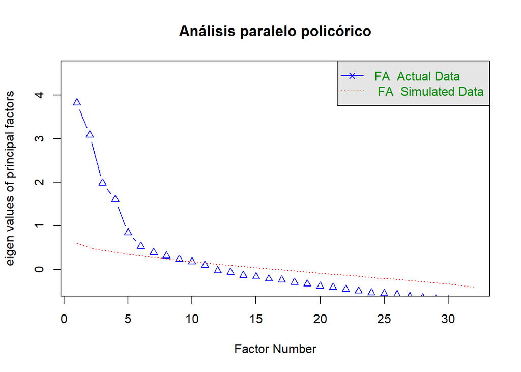

```
## Parallel analysis suggests that the number of factors =  8  and the number of components =  NA
```

```r
set.seed(2026)
psych::fa.parallel(rho_afe,n.obs=nrow(X_afe),fa="fa",fm="minres",n.iter=500,
                   main="Análisis paralelo policórico")
```

# 5 AFE iterativo para 4, 6 y 8 factores

```r
evaluar_afe <- function(R,k,nobs){
  mod <- psych::fa(R,nfactors=k,n.obs=nobs,fm="minres",rotate="oblimin")
  L <- as.data.frame(unclass(mod$loadings)); absL <- abs(as.matrix(L))
  ord <- t(apply(absL,1,sort,decreasing=TRUE))
  diag <- tibble(variable=rownames(L),factor=apply(absL,1,which.max),
                 carga_principal=ord[,1],carga_secundaria=ord[,2],
                 diferencia=ord[,1]-ord[,2],comunalidad=mod$communality,
                 cumple=carga_principal>=.40 & carga_secundaria<.35 &
                        diferencia>=.20 & comunalidad>=.25)
  list(modelo=mod,cargas=L,diagnostico=diag)
}

depurar_iterativo <- function(datos,k){
  actuales <- names(datos); bitacora <- list(); minimo_total <- 2L*k
  max_iter <- length(actuales)-minimo_total; z <- NULL
  for(i in seq_len(max_iter+1L)){
    R <- psych::polychoric(datos[,actuales,drop=FALSE])$rho
    dimnames(R) <- list(actuales,actuales)
    z <- evaluar_afe(R,k,nrow(datos)); malos <- z$diagnostico |> filter(!cumple)
    if(!nrow(malos)) break
    if(length(actuales)<=minimo_total || i>max_iter) break
    candidato <- malos |>
      mutate(severidad=pmax(0,.40-carga_principal)+pmax(0,carga_secundaria-.35)+
                        pmax(0,.20-diferencia)+pmax(0,.25-comunalidad)) |>
      arrange(desc(severidad),carga_principal,comunalidad) |> slice(1)
    bitacora[[length(bitacora)+1L]] <- candidato |> mutate(iteracion=i,decision="Eliminar",solucion=k)
    n_antes <- length(actuales)
    actuales <- setdiff(actuales,as.character(candidato$variable))
    if(length(actuales)!=n_antes-1L) stop("No se retiró el ítem ",candidato$variable)
  }
  asignacion <- z$diagnostico |> count(factor,name="n_indicadores")
  list(k=k,items=actuales,resultado=z,bitacora=bind_rows(bitacora),
       converge=all(z$diagnostico$cumple),incumplimientos=sum(!z$diagnostico$cumple),
       minimo_factor=min(asignacion$n_indicadores),tam_factores=asignacion)
}
```

```r
soluciones <- lapply(c(4,6,8),function(k) depurar_iterativo(X_afe,k))
names(soluciones) <- paste0("F",c(4,6,8))
for(s in soluciones){
  write.csv(s$resultado$cargas,sprintf("resultados/cargas_AFE_%s_factores.csv",s$k))
  write.csv(s$resultado$diagnostico,sprintf("resultados/diagnostico_AFE_%s_factores.csv",s$k),row.names=FALSE)
}
bitacora <- bind_rows(lapply(soluciones,`[[`,"bitacora"))
write.csv(bitacora,"resultados/12_bitacora_depuracion.csv",row.names=FALSE)
comparacion_afe <- bind_rows(lapply(soluciones,function(s)tibble(
  factores=s$k,items=length(s$items),varianza=sum(s$resultado$modelo$Vaccounted[2,]),
  incumplimientos=s$incumplimientos,converge=s$converge,minimo_indicadores=s$minimo_factor,
  elegible_afc=s$converge && s$minimo_factor>=2)))
write.csv(comparacion_afe,"resultados/15_comparacion_AFE_4_6_8.csv",row.names=FALSE)
knitr::kable(comparacion_afe,digits=3)
```

| factores | items | varianza | incumplimientos | converge | minimo_indicadores | elegible_afc |
| --- | --- | --- | --- | --- | --- | --- |
| 4 | 14 | 0.544 | 0 | TRUE | 2 | TRUE |
| 6 | 23 | 0.507 | 0 | TRUE | 2 | TRUE |
| 8 | 18 | 0.625 | 0 | TRUE | 1 | FALSE |

# 6 Generación automática y evaluación de modelos AFC

```r
crear_sintaxis <- function(sol){
  d <- sol$resultado$diagnostico |> arrange(factor,desc(carga_principal))
  grupos <- split(d$variable,d$factor)
  lineas <- character()
  for(i in seq_along(grupos)){
    its <- grupos[[i]]
    if(length(its)<2L) return(NA_character_)
    rhs <- if(length(its)==2L) paste0("l",i,"*",its,collapse=" + ") else paste(its,collapse=" + ")
    lineas <- c(lineas,paste0("F",i," =~ ",rhs))
  }
  paste(lineas,collapse="\n")
}

ajustar_candidato <- function(sol,datos){
  sintaxis <- crear_sintaxis(sol)
  if(is.na(sintaxis)) return(list(ok=FALSE,motivo="Factor con menos de 2 indicadores"))
  items <- sol$items
  ajuste <- tryCatch(lavaan::cfa(sintaxis,data=datos,ordered=items,estimator="WLSMV",std.lv=TRUE),
                     error=function(e)e)
  if(inherits(ajuste,"error")) return(list(ok=FALSE,motivo=conditionMessage(ajuste),sintaxis=sintaxis))
  if(!lavInspect(ajuste,"converged")) return(list(ok=FALSE,motivo="No convergió",sintaxis=sintaxis))
  std <- standardizedSolution(ajuste); cargas <- std |> filter(op=="=~")
  theta <- diag(lavInspect(ajuste,"theta"))
  impropio <- any(theta<0) || any(abs(cargas$est.std)>1) || any(cargas$est.std^2>1)
  idxn <- c("chisq.scaled","df.scaled","pvalue.scaled","cfi.robust","tli.robust",
            "rmsea.robust","rmsea.ci.lower.robust","rmsea.ci.upper.robust","srmr")
  fm <- fitMeasures(ajuste,idxn)
  score <- unname(fm["cfi.robust"]+fm["tli.robust"]-fm["rmsea.robust"]-fm["srmr"])
  list(ok=TRUE,admisible=!impropio,ajuste=ajuste,sintaxis=sintaxis,cargas=cargas,
       indices=fm,score=score,motivo=if(impropio)"Solución impropia" else "Admisible")
}
```

```r
modelos_afc <- lapply(soluciones,function(s) ajustar_candidato(s,X_afc))
resumen_afc <- bind_rows(Map(function(nombre,obj){
  if(!isTRUE(obj$ok)) return(tibble(modelo=nombre,ejecutado=FALSE,admisible=FALSE,motivo=obj$motivo))
  tibble(modelo=nombre,ejecutado=TRUE,admisible=obj$admisible,motivo=obj$motivo,
         chisq=unname(obj$indices["chisq.scaled"]),gl=unname(obj$indices["df.scaled"]),
         CFI=unname(obj$indices["cfi.robust"]),TLI=unname(obj$indices["tli.robust"]),
         RMSEA=unname(obj$indices["rmsea.robust"]),SRMR=unname(obj$indices["srmr"]),score=obj$score)
},names(modelos_afc),modelos_afc))
write.csv(resumen_afc,"resultados/20_comparacion_AFC_4_6_8.csv",row.names=FALSE)
knitr::kable(resumen_afc,digits=3)
```

| modelo | ejecutado | admisible | motivo | chisq | gl | CFI | TLI | RMSEA | SRMR | score |
| --- | --- | --- | --- | --- | --- | --- | --- | --- | --- | --- |
| F4 | TRUE | TRUE | Admisible | 314.225 | 72 | 0.854 | 0.816 | 0.100 | 0.084 | 1.487 |
| F6 | TRUE | FALSE | Solución impropia | 855.535 | 216 | 0.739 | 0.694 | 0.097 | 0.091 | 1.243 |
| F8 | FALSE | FALSE | Factor con menos de 2 indicadores | NA | NA | NA | NA | NA | NA | NA |

```r
admisibles <- resumen_afc |> filter(ejecutado,admisible)
if(!nrow(admisibles)) stop("Ninguno de los modelos AFC fue admisible. No se generan conclusiones finales.")
mejor_nombre <- admisibles |> arrange(desc(score),desc(CFI),RMSEA) |> slice(1) |> pull(modelo)
modelo_final <- modelos_afc[[mejor_nombre]]
solucion_final <- soluciones[[mejor_nombre]]
writeLines(modelo_final$sintaxis,"resultados/21_sintaxis_modelo_final.txt")
write.csv(modelo_final$cargas,"resultados/22_cargas_modelo_final.csv",row.names=FALSE)
jsonlite::write_json(list(modelo_final=mejor_nombre,criterio="Mayor score entre modelos admisibles",
                          score=modelo_final$score),"resultados/23_decision_modelo_final.json",pretty=TRUE,auto_unbox=TRUE)
```

# 7 Fiabilidad y validez del modelo final admisible

```r
ajuste_final <- modelo_final$ajuste
cr <- semTools::compRelSEM(ajuste_final); ave <- semTools::AVE(ajuste_final)
calidad <- data.frame(factor=names(cr),CR=as.numeric(cr),AVE=as.numeric(ave[names(cr)]))
write.csv(calidad,"resultados/31_CR_AVE_modelo_final.csv",row.names=FALSE)
htmt <- semTools::htmt(modelo_final$sintaxis,data=X_afc,ordered=solucion_final$items)
write.csv(as.data.frame(htmt),"resultados/33_HTMT_modelo_final.csv")
knitr::kable(calidad,digits=3)
```

| factor | CR | AVE |
| --- | --- | --- |
| F1 | 0.850 | 0.723 |
| F2 | 0.747 | 0.440 |
| F3 | 0.678 | 0.399 |
| F4 | 0.647 | 0.532 |

# 8 Sensibilidad con MLR

```r
X_afc_num <- X_afc |> mutate(across(everything(),as.numeric))
ajuste_mlr <- lavaan::cfa(modelo_final$sintaxis,data=X_afc_num,estimator="MLR",std.lv=TRUE,missing="fiml")
comparar_estimadores <- rbind(
  WLSMV=fitMeasures(ajuste_final,c("cfi.robust","tli.robust","rmsea.robust","srmr")),
  MLR=fitMeasures(ajuste_mlr,c("cfi.robust","tli.robust","rmsea.robust","srmr")))
write.csv(comparar_estimadores,"resultados/35_sensibilidad_WLSMV_MLR.csv")
knitr::kable(comparar_estimadores,digits=3)
```

|  | cfi.robust | tli.robust | rmsea.robust | srmr |
| --- | --- | --- | --- | --- |
| WLSMV | 0.854 | 0.816 | 0.100 | 0.084 |
| MLR | 0.888 | 0.858 | 0.074 | 0.069 |

# 9 Conclusión automatizada

El modelo seleccionado es F4, elegido únicamente entre soluciones confirmatorias admisibles. La estructura final contiene 4 factores y 14 indicadores. Los índices robustos fueron CFI = 0.854, TLI = 0.816, RMSEA = 0.1 y SRMR = 0.084. La interpretación debe considerar conjuntamente estos índices, la fiabilidad, la validez convergente, HTMT, la parsimonia y la cobertura conceptual de cada factor.

# 10 Limitaciones

La muestra es no probabilística y procede de una encuesta aplicada en un contexto específico. La eliminación por casos completos excluye registros con al menos un dato ausente. La selección entre estructuras depende de los criterios declarados y requiere validación externa en otra muestra antes de generalizar resultados o utilizar puntuaciones individuales para decisiones de alto impacto.